# Perio data attempt

This is an attempt at tidying some of the perio data

Lets try to make it so that the .xlsx file is automatically turned into a .csv so that people don’t have to do it manually in excel

### data imports

```r
#import .csv files
sub1 <- read.csv("C:/Users/Felix/Dropbox/Rfun/Felix/Felix/aim 3 REDCaps/REDCap033_ESE_bopcal_SA3_v2.1_20160211_dd - Copy_fc.csv", comment.char="#")
sub2 <- read.csv("C:/Users/Felix/Dropbox/Rfun/Felix/Felix/aim 3 REDCaps/REDCap052_ESE_bopcal_SA3_v2.1_20160223_dd - Copy_fc.csv", comment.char="#")
sub3 <- read.csv("C:/Users/Felix/Dropbox/Rfun/Felix/Felix/aim 3 REDCaps/REDCap054_ESE_bopcal_SA3_v2.1_20160223_dd - Copy_fc.csv", comment.char="#")
sub4 <- read.csv("C:/Users/Felix/Dropbox/Rfun/Felix/Felix/aim 3 REDCaps/REDCap065_ESE_bopcal_SA3_v2.1_20160225_dd - Copy_fc.csv", comment.char="#")
sub5 <- read.csv("C:/Users/Felix/Dropbox/Rfun/Felix/Felix/aim 3 REDCaps/REDCap066_ESE_bopcal_SA3_v2.1_20160308_dd - Copy_fc.csv", comment.char="#")
sub6 <- read.csv("C:/Users/Felix/Dropbox/Rfun/Felix/Felix/aim 3 REDCaps/REDCap080_ESE_bopcal_SA3_v2.1_20160308_dd - Copy_fc.csv", comment.char="#")
sub7 <- read.csv("C:/Users/Felix/Dropbox/Rfun/Felix/Felix/aim 3 REDCaps/REDCap089_ESE_bopcal_SA3_v2.1_20160308_dd - Copy_fc.csv", comment.char="#")
sub8 <- read.csv("C:/Users/Felix/Dropbox/Rfun/Felix/Felix/aim 3 REDCaps/REDCap101_ESE_bopcal_SA3_v2.1_20160309_dd - Copy_fc.csv", comment.char="#")
sub9 <- read.csv("C:/Users/Felix/Dropbox/Rfun/Felix/Felix/aim 3 REDCaps/REDCap200_ESE_bopcal_SA3_v2.1_20151112_dd_fc.csv", comment.char="#")
sub10 <- read.csv("C:/Users/Felix/Dropbox/Rfun/Felix/Felix/aim 3 REDCaps/REDCap283_ESE_bopcal_SA3_v2.1_20160201_SK - Copy_fc.csv", comment.char="#")

########### importing data for aim 1##########

sub11 <- read.csv("C:/Users/Felix/Dropbox/Rfun/Felix/Felix/aim 1 REDCaps/REDCap017_ESE_bopcal_SA1_v2.1_20160112_nmd.csv", comment.char="#")
sub12 <- read.csv("C:/Users/Felix/Dropbox/Rfun/Felix/Felix/aim 1 REDCaps/REDCap023_ESE_bopcal_SA1_v2.1_20160210_dd.csv", comment.char="#")
sub13 <- read.csv("C:/Users/Felix/Dropbox/Rfun/Felix/Felix/aim 1 REDCaps/REDCap032_ESE_bopcal_SA1_v2.1_20160210_dd.csv", comment.char="#")
sub14 <- read.csv("C:/Users/Felix/Dropbox/Rfun/Felix/Felix/aim 1 REDCaps/REDCap036_ESE_bopcal_v2.1_SA1_20160211_dd.csv", comment.char="#")
sub15 <- read.csv("C:/Users/Felix/Dropbox/Rfun/Felix/Felix/aim 1 REDCaps/REDCap039_ESE_bopcal_SA1_v2.1_20160211_dd.csv", comment.char="#")
sub16 <- read.csv("C:/Users/Felix/Dropbox/Rfun/Felix/Felix/aim 1 REDCaps/REDCap040_ESE_bopcal_SA1_v2.1_20160211_dd.csv", comment.char="#")
sub17 <- read.csv("C:/Users/Felix/Dropbox/Rfun/Felix/Felix/aim 1 REDCaps/REDCap044_ESE_bopcal_SA1_v2.1_20160218_dd.csv", comment.char="#")
sub18 <- read.csv("C:/Users/Felix/Dropbox/Rfun/Felix/Felix/aim 1 REDCaps/REDCap045_ESE_bopcal_SA1_v2.1_20160218_dd.csv", comment.char="#")
sub19 <- read.csv("C:/Users/Felix/Dropbox/Rfun/Felix/Felix/aim 1 REDCaps/REDCap046_ESE_bopcal_SA1_v2.1_20160218_dd.csv", comment.char="#")
sub20 <- read.csv("C:/Users/Felix/Dropbox/Rfun/Felix/Felix/aim 1 REDCaps/REDCap049_ESE_bopcal_SA1_v2.1_20160222_dd.csv", comment.char="#")
sub21 <- read.csv("C:/Users/Felix/Dropbox/Rfun/Felix/Felix/aim 2 REDCaps/REDCap018_ESE_bopcal_SA2_v2.1_20160112_nmd.csv", comment.char="#")
sub22 <- read.csv("C:/Users/Felix/Dropbox/Rfun/Felix/Felix/aim 2 REDCaps/REDCap270_ESE_bopcal_SA2_v2.1_20151104_nmd.csv", comment.char="#")
sub23 <- read.csv("C:/Users/Felix/Dropbox/Rfun/Felix/Felix/aim 2 REDCaps/REDCap281_ESE_bopcal_SA2_v2.1_20160125_SK.csv", comment.char="#")
sub24 <- read.csv("C:/Users/Felix/Dropbox/Rfun/Felix/Felix/aim 2 REDCaps/REDCap288_ESE_bopcal_SA2_v2.1_20160301_dd.csv", comment.char="#")
sub25 <- read.csv("C:/Users/Felix/Dropbox/Rfun/Felix/Felix/aim 2 REDCaps/REDCap294_ESE_bopcal_SA2_v2.2_20160321_SK.xlsx 2.csv", comment.char="#")
sub26 <- read.csv("C:/Users/Felix/Dropbox/Rfun/Felix/Felix/aim 1 REDCaps/REDCap056_ESE_bopcal_SA1_v2.1_20160223_dd 2.csv", comment.char="#")
sub27 <- read.csv("C:/Users/Felix/Dropbox/Rfun/Felix/Felix/aim 1 REDCaps/REDCap062_ESE_bopcal_SA1_v2.1_20160225_dd.csv", comment.char="#")
sub28 <- read.csv("C:/Users/Felix/Dropbox/Rfun/Felix/Felix/aim 1 REDCaps/REDCap063_ESE_bopcal_SA1_v2.1_20160225_dd.csv", comment.char="#")
sub29 <- read.csv("C:/Users/Felix/Dropbox/Rfun/Felix/Felix/aim 1 REDCaps/REDCap072_ESE_bopcal_SA1_v2.1_20160308_dd.csv", comment.char="#")
sub30 <- read.csv("C:/Users/Felix/Dropbox/Rfun/Felix/Felix/aim 1 REDCaps/REDCap091_ESE_bopcal_SA1_v2.1_20160308_dd.csv", comment.char="#")
sub31 <- read.csv("C:/Users/Felix/Dropbox/Rfun/Felix/Felix/aim 1 REDCaps/REDCap093_ESE_bopcal_SA1_v2.1_20160308_dd - Copy.csv", comment.char="#")
sub32 <- read.csv("C:/Users/Felix/Dropbox/Rfun/Felix/Felix/aim 1 REDCaps/REDCap099_ESE_bopcal_SA1_v2.1_20160309.csv", comment.char="#")
sub33 <- read.csv("C:/Users/Felix/Dropbox/Rfun/Felix/Felix/aim 1 REDCaps/REDCap121_ESE_bopcal_SA1_v2.1_20160309_dd.csv", comment.char="#")
sub34 <- read.csv("C:/Users/Felix/Dropbox/Rfun/Felix/Felix/aim 1 REDCaps/REDCap143_ESE_bopcal_SA1_v2.1_20160310_dd.csv", comment.char="#")
sub35 <- read.csv("C:/Users/Felix/Dropbox/Rfun/Felix/Felix/aim 1 REDCaps/REDCap202_ESE_bopcal_SA1_v2.1_20151104_nmd.csv", comment.char="#")
sub36 <- read.csv("C:/Users/Felix/Dropbox/Rfun/Felix/Felix/aim 1 REDCaps/REDCap254_ESE_bopcal_SA1_v2.1_20151104_nmd.csv", comment.char="#")
sub37 <- read.csv("C:/Users/Felix/Dropbox/Rfun/Felix/Felix/aim 1 REDCaps/REDCap277_ESE_bopcal_SA1_v2.1_20151104_nmd.csv", comment.char="#")
sub38 <- read.csv("C:/Users/Felix/Dropbox/Rfun/Felix/Felix/aim 1 REDCaps/REDCap289_ESE_bopcal_SA1_v2.1_20160311_nmd.csv", comment.char="#")

#aim1, I kinda messed up so its grabbing these files from the folder messy, but the folder messy is in the wrong REDCap folder. I also did not add a sub40, because i forgot

sub39 <- read.csv("C:/Users/Felix/Dropbox/Rfun/Felix/Felix/aim 3 REDCaps/messy/REDCap93_ESE_bopcal_Aim1_v3.0_2016MMDD.csv", comment.char="#")
sub40 <- read.csv("C:/Users/Felix/Dropbox/Rfun/Felix/Felix/aim 3 REDCaps/messy/2.0/REDCap274_ESE_bopcal_SA1_v2.0_20151104_nmd.csv", comment.char="#")
sub41 <- read.csv("C:/Users/Felix/Dropbox/Rfun/Felix/Felix/aim 3 REDCaps/messy/REDCAP298,SCREEN48_ESE_bopcal_v2.2_sa1_20160420_NMD.csv", comment.char="#")
sub42 <- read.csv("C:/Users/Felix/Dropbox/Rfun/Felix/Felix/aim 3 REDCaps/messy/Redcap299_ESE_bopcal_SA1_041916_dd.csv", comment.char="#")
sub43 <- read.csv("C:/Users/Felix/Dropbox/Rfun/Felix/Felix/aim 3 REDCaps/messy/Redcap300_SA1_ESE_bopcal_v2.2_05032016_dd 2.csv", comment.char="#")
sub44 <- read.csv("C:/Users/Felix/Dropbox/Rfun/Felix/Felix/aim 3 REDCaps/messy/REDCap308_ESE_bopcal_SA1_v3.0_20160701.csv", comment.char="#")
sub45 <- read.csv("C:/Users/Felix/Dropbox/Rfun/Felix/Felix/aim 3 REDCaps/messy/REDCap309_ESE_bopcal_SA1_v2.2_20160627.csv", comment.char="#")
sub46 <- read.csv("C:/Users/Felix/Dropbox/Rfun/Felix/Felix/aim 3 REDCaps/messy/REDCap310_ESE_bopcal_SA1_v2.2_20160627.csv", comment.char="#")
sub47 <- read.csv("C:/Users/Felix/Dropbox/Rfun/Felix/Felix/aim 3 REDCaps/messy/REDCap313_ESE_bopcal_SA1_v3.0_20160711_SEW.csv", comment.char="#")


#messydata <- read.csv("C:/Users/Felix/Dropbox/Rfun/Felix/Felix/aim 3 REDCaps/REDCap033_ESE_bopcal_SA3_v2.1_20160211_dd - Copy.csv", comment.char="#")
```

1. BOP, CAL, PB as a function of aim
- geom_boxplot()
- geom_bar() Figure out difference between ggplot geom_boxplot and a “normal” boxplot
2. Whether our measurements vary based on tooth site and aim +geom_boxplot()

facet_wrap on variable

PD BOP GM.CEJ CAL Site are the variables # tidy the data for sub1

```r
#trying to write a function to make this thing take up less lines

tidy_pls <- function(x, print = TRUE){
    no.top <- x[7:31,]
  library(reshape2)
    transposed <- t(no.top)
    tidy.sub <- data.frame(rbind(transposed[-1, 1:5], transposed[-1, 7:11], transposed[-1, 15:19], transposed[-1, 21:25]))
    colnames(tidy.sub) <- c("site", "PD", "BOP", "GM.CEJ", "CAL")
    tidy.sub$date.raw <- x[2,2]
    tidy.sub$data.recorder <- x[3,2]
    tidy.sub$clinician <- x[4,2]
    #############################
    tidy.sub$aim <- "SA3"
    #CHANGE THE ABOVE THING LATER

    return(tidy.sub)
}

tidy_pls2 <- function(x, print = TRUE){
    no.top <- x[7:31,]
  library(reshape2)
    transposed <- t(no.top)
    tidy.sub <- data.frame(rbind(transposed[-1, 1:5], transposed[-1, 7:11], transposed[-1, 15:19], transposed[-1, 21:25]))
    colnames(tidy.sub) <- c("site", "PD", "BOP", "GM.CEJ", "CAL")
    tidy.sub$date.raw <- x[2,2]
    tidy.sub$data.recorder <- x[3,2]
    tidy.sub$clinician <- x[4,2]
    #############################
    tidy.sub$aim <- "SA1"
    #CHANGE THE ABOVE THING LATER

    return(tidy.sub)
}

tidy_pls3 <- function(x, print = TRUE){
    no.top <- x[7:31,]
  library(reshape2)
    transposed <- t(no.top)
    tidy.sub <- data.frame(rbind(transposed[-1, 1:5], transposed[-1, 7:11], transposed[-1, 15:19], transposed[-1, 21:25]))
    colnames(tidy.sub) <- c("site", "PD", "BOP", "GM.CEJ", "CAL")
    tidy.sub$date.raw <- x[2,2]
    tidy.sub$data.recorder <- x[3,2]
    tidy.sub$clinician <- x[4,2]
    #############################
    tidy.sub$aim <- "SA2"
    #CHANGE THE ABOVE THING LATER

    return(tidy.sub)
}

tidy_pls4 <- function(x, print = TRUE){
    no.top <- x[6:28,]
  library(reshape2)
    transposed <- t(no.top)
    tidy.sub <- data.frame(rbind(transposed[-1, 1:5], transposed[-1, 7:11], transposed[-1, 13:17], transposed[-1, 19:23]))
    colnames(tidy.sub) <- c("site", "PD", "BOP", "GM.CEJ", "CAL")
    tidy.sub$date.raw <- x[1,9]
    tidy.sub$data.recorder <- x[2,9]
    tidy.sub$clinician <- x[3,9]
    #############################
    tidy.sub$aim <- "SA1"
    #CHANGE THE ABOVE THING LATER

    return(tidy.sub)
}

tidy.sub1 <- tidy_pls(sub1)
tidy.sub2 <- tidy_pls(sub2)
tidy.sub3 <- tidy_pls(sub3)
tidy.sub4 <- tidy_pls(sub4)
tidy.sub5 <- tidy_pls(sub5)
tidy.sub6 <- tidy_pls(sub6)
tidy.sub7 <- tidy_pls(sub7)
tidy.sub8 <- tidy_pls(sub8)
tidy.sub9 <- tidy_pls(sub9)
tidy.sub10 <- tidy_pls(sub10)
tidy.sub11 <- tidy_pls2(sub11)
tidy.sub12 <- tidy_pls2(sub12)
tidy.sub13 <- tidy_pls2(sub13)
tidy.sub14 <- tidy_pls2(sub14)
tidy.sub15 <- tidy_pls2(sub15)
tidy.sub16 <- tidy_pls2(sub16)
tidy.sub17 <- tidy_pls2(sub17)
tidy.sub18 <- tidy_pls2(sub18)
tidy.sub19 <- tidy_pls2(sub19)
tidy.sub20 <- tidy_pls2(sub20)
tidy.sub26 <- tidy_pls2(sub26)
tidy.sub28 <- tidy_pls2(sub28)
tidy.sub29 <- tidy_pls2(sub29)
tidy.sub30 <- tidy_pls2(sub30)
tidy.sub31 <- tidy_pls2(sub31)
tidy.sub32 <- tidy_pls2(sub32)
tidy.sub33 <- tidy_pls2(sub33)
tidy.sub34 <- tidy_pls2(sub34)
tidy.sub35 <- tidy_pls2(sub35)
tidy.sub36 <- tidy_pls2(sub36)
tidy.sub37 <- tidy_pls2(sub37)
tidy.sub38 <- tidy_pls2(sub38)
tidy.sub27 <- tidy_pls2(sub27)
tidy.sub40 <- tidy_pls2(sub40)
tidy.sub21 <- tidy_pls3(sub21)
tidy.sub22 <- tidy_pls3(sub22)
tidy.sub23 <- tidy_pls3(sub23)
tidy.sub24 <- tidy_pls3(sub24)
tidy.sub25 <- tidy_pls3(sub25)
tidy.sub39 <- tidy_pls4(sub39)
tidy.sub41 <- tidy_pls4(sub41)
tidy.sub42 <- tidy_pls4(sub42)
tidy.sub43 <- tidy_pls4(sub43)
tidy.sub44 <- tidy_pls4(sub44)
tidy.sub45 <- tidy_pls4(sub45)
tidy.sub46 <- tidy_pls4(sub46)
tidy.sub47 <- tidy_pls4(sub47)
########### FIND A BETTER WAY TO DO THE THING BELOW #############

tidy.sub1$subject <- "REDCap_0033"
tidy.sub2$subject <- "REDCap_0052"
tidy.sub3$subject <- "REDCap_0054"
tidy.sub4$subject <- "REDCap_0065"
tidy.sub5$subject <- "REDCap_0066"
tidy.sub6$subject <- "REDCap_0080"
tidy.sub7$subject <- "REDCap_0089"
tidy.sub8$subject <- "REDCap_0101"
tidy.sub9$subject <- "REDCap_0200"
tidy.sub10$subject <- "REDCap_0283"
tidy.sub11$subject <- "REDCap_0017"
tidy.sub12$subject <- "REDCap_0023"
tidy.sub13$subject <- "REDCap_0032"
tidy.sub14$subject <- "REDCap_0036"
tidy.sub15$subject <- "REDCap_0039"
tidy.sub16$subject <- "REDCap_0040"
tidy.sub17$subject <- "REDCap_0044"
tidy.sub18$subject <- "REDCap_0045"
tidy.sub19$subject <- "REDCap_0046"
tidy.sub20$subject <- "REDCap_0049"
tidy.sub21$subject <- "REDCap_0018"
tidy.sub22$subject <- "REDCap_0270"
tidy.sub23$subject <- "REDCap_0281"
tidy.sub24$subject <- "REDCap_0288"
tidy.sub25$subject <- "REDCap_0294"
tidy.sub26$subject <- "REDCap_0056"
tidy.sub27$subject <- "REDCap_0062"
tidy.sub28$subject <- "REDCap_0063"
tidy.sub29$subject <- "REDCap_0072"
tidy.sub30$subject <- "REDCap_0091"
tidy.sub31$subject <- "REDCap_0093"
tidy.sub32$subject <- "REDCap_0099"
tidy.sub33$subject <- "REDCap_0121"
tidy.sub34$subject <- "REDCap_0143"
tidy.sub35$subject <- "REDCap_0202"
tidy.sub36$subject <- "REDCap_0254"
tidy.sub37$subject <- "REDCap_0277"
tidy.sub38$subject <- "REDCap_0289"
tidy.sub39$subject <- "REDCap_0093"
tidy.sub40$subject <- "REDCap_0274"
tidy.sub41$subject <- "REDCap_0298"
tidy.sub42$subject <- "REDCap_0299"
tidy.sub43$subject <- "REDCap_0300"
tidy.sub44$subject <- "REDCap_0308"
tidy.sub45$subject <- "REDCap_0309"
tidy.sub46$subject <- "REDCap_0310"
tidy.sub47$subject <- "REDCap_0313"



#tidy.df$subject <- "Felix" #enter the subject from the redcap file, "REDCap_0001"
#tidy.df$aim <- "SA3" #enter the aim as either "SA1", "SA2", or "SA3"


#stacking all of the data frames

# vvv OP stuff that I should try and remember

#taken out

#spliting the site variable by "."

#library("reshape2");library("stringr")
#foo <- data.frame(tidy.df$Site)
#colnames(foo) <- "habitat"
#foo2 <- colsplit(foo$habitat, "[(.)]", names=c("site", "tooth"))
#df10 <- data.frame(tidy.df, foo2)

# ^^^ OP stff that I should try and remember

#ASK ABOUT THIS PART VVV

#another way to add a variable called "subject"
#tidy.df$subject <- "Felix" #enter the subject from the redcap file, "REDCap_0001"
#tidy.df$aim <- "SA3" #enter the aim as either "SA1", "SA2", or "SA3"

################################# merge subjects here vvv

bound.subs <- rbind(tidy.sub1, tidy.sub2, tidy.sub3, tidy.sub4, tidy.sub5, tidy.sub6, tidy.sub7, tidy.sub8, tidy.sub9, tidy.sub10, tidy.sub11, tidy.sub12, tidy.sub13, tidy.sub14, tidy.sub15, tidy.sub16, tidy.sub17, tidy.sub18, tidy.sub19, tidy.sub20, tidy.sub21, tidy.sub22, tidy.sub23, tidy.sub24, tidy.sub25, tidy.sub26, tidy.sub27, tidy.sub28, tidy.sub29, tidy.sub30, tidy.sub31, tidy.sub32, tidy.sub33, tidy.sub34, tidy.sub35, tidy.sub36, tidy.sub37, tidy.sub38, tidy.sub39, tidy.sub40, tidy.sub41, tidy.sub42, tidy.sub43, tidy.sub44, tidy.sub45, tidy.sub46, tidy.sub47)

################################# merge subjects here ^^^

aim1 <- rbind(tidy.sub11, tidy.sub12, tidy.sub13, tidy.sub14, tidy.sub15, tidy.sub16, tidy.sub17, tidy.sub18, tidy.sub19, tidy.sub20, tidy.sub26, tidy.sub27, tidy.sub28, tidy.sub29, tidy.sub30, tidy.sub31, tidy.sub32, tidy.sub33, tidy.sub34, tidy.sub35, tidy.sub36, tidy.sub37, tidy.sub38, tidy.sub39, tidy.sub40, tidy.sub41, tidy.sub42, tidy.sub43, tidy.sub44, tidy.sub45, tidy.sub46, tidy.sub47)
aim3 <- rbind(tidy.sub1, tidy.sub2, tidy.sub3, tidy.sub4, tidy.sub5, tidy.sub6, tidy.sub7, tidy.sub8, tidy.sub9, tidy.sub10)
aim2 <- rbind(tidy.sub21, tidy.sub22, tidy.sub23, tidy.sub24, tidy.sub25)

#cleaning some stuff up, and separating columns

bound.subs2 <- data.frame(colsplit(bound.subs$site, "[(.)]", names = c("site", "tooth")), bound.subs)
#would probably do the step above a lot earlier if things weren't in a "DB.1" format
bound.subs3 <- bound.subs2



library(tidyr)
library(stringr)
  sub.tidy.perio <- separate(bound.subs3, site, c("site", "aspect"), sep = -2)
  sub.tidy.perio$aspect <- str_replace_all(sub.tidy.perio$aspect, "B", "Buccal")
  sub.tidy.perio$aspect <- str_replace_all(sub.tidy.perio$aspect, "L", "Lingual")
  tidy.perio1 <- colsplit(sub.tidy.perio$date.raw, "[(;)]", names = c("date.entry", "date.exam"))
library(stringr)
  tidy.perio1$date.exam <- str_replace(tidy.perio1$date.exam, "exam completed on ", "")

tidy.perio2 <- data.frame(sub.tidy.perio, tidy.perio1)[,-9]
names(tidy.perio2)[4] <- "tooth.and.site"

#melting "PD", "BOP", "GM.CEJ", and "CAL" into one variable

library(reshape2)
  final.sub <- melt(tidy.perio2, id = c("site", "aspect", "tooth", "data.recorder", "clinician", "subject", "date.entry", "date.exam", "aim", "tooth.and.site"))
```

The stuff below is me trying to make functions to make stuff more generalized and easier

edit: the first function is pretty much useless now, because the second one works

```r
#CAL stuff

###### lets make a function because why not!!! ######

# must be in tidy.sub[numer_here] format
  # for example, get_avg_cal(tidy.sub1)

get_avg_cal <- function(x, print = TRUE){
  #i think this function only works for very specific things like finding the CAL for this specific type of dataset. If the class of certain things were changed around, then this function would probably not work anymore
      num1 <- as.numeric(as.vector(x$PD))
      val1 <- sum(num1[complete.cases(num1)])
      count1 <- sum(is.na(num1) == FALSE)
      num2 <- as.numeric(as.vector(x$GM.CEJ))
      val2 <- sum(num2[complete.cases(num2)])
      CAL <- (val1 + val2)/count1

      return(CAL)
}

get_pd <- function(x, print = TRUE){
      num1 <- as.numeric(as.vector(x$PD))
      val1 <- sum(num1[complete.cases(num1)])
      count1 <- sum(is.na(num1) == FALSE)
      PD <- val1/count1

      return(PD)
}

# i'm going to try to do the exact same function shown above, but instead, it will use the really big data frame instead. This might end up with it being more complex and worse overall
avg_cal <- function(x, y, print = TRUE){
# 'x' is data frame name and 'y' is REDCap number in 'REDCap_[####]' format (EX: avg_cal(final.sub, "REDCap_0033"))

redcap.PD <- subset(x, subject == y & variable == 'PD', select = value)
      num1 <- as.numeric(as.vector(redcap.PD$value))
        val1 <- sum(num1[complete.cases(num1)])
          count1 <- sum(is.na(num1) == FALSE)
redcap.GM.CEJ <- subset(x, subject == y & variable == 'GM.CEJ', select = value)
      num2 <- as.numeric(as.vector(redcap.GM.CEJ$value))
        val2 <- sum(num2[complete.cases(num2)])
CAL <- (val1 + val2)/count1
return(CAL)
}
ladwew <- avg_cal(final.sub, "REDCap_0033", print = TRUE)
```

I think this thing is for the % BOP. As with the average CAL, I will have two ways of doing it. A bad way which requires you to enter in “tidy.sub1”, or whatever, and a good way where you only have to enter the really big data frame and the REDCap number

```r
######## BELOW IS HOW I USED TO DO IT BEFORE I WROTE THE FUNCTION #####

  #sum((as.numeric(as.vector(x)))[complete.cases(as.numeric(as.vector(x)))])
#test4 <- as.numeric(as.vector(tidy.sub1$PD))
#test7 <- test4[complete.cases(test4)]
#doot <- is.na(test4)
#sub1.count <- sum(doot == FALSE)
#sub1.count <- sum(count(test7))
#test3 <- as.numeric(as.vector(tidy.sub1$`GM.CEJ`))
#test6 <- test3[complete.cases(test3)]

#sub1.sum.GM.CEJ <- sum(test6)
#sub1.sum.PD <- sum(test7)
 # sub1.sum.yay <- sub1.sum.GM.CEJ + sub1.sum.PD
  #  sub1.CAL <- sub1.sum.yay / sub1.count

#########################################################################################

# %BOP stuff and an attempt to write another function

pct_bop <- function(x, print = TRUE){
  #like the get_avg_cal() function, this one is probably very specific, and only works with data sets which are in the same format as these ones
    num1 <- as.numeric(as.vector(x$BOP))
    val1 <- sum(num1[complete.cases(num1)])
    count1 <- sum(is.na(num1) == FALSE)

    BOP <- val1/count1

    return(BOP)
}



########## i gave up on trying to use summaryBy to calculate the average CAL and %BOP ############

#library(doBy)
#    sub1.CALculations <- summaryBy(PD + `GM.CEJ`~subject, data = tidy.sub1, FUN = c(mean, length, sum))
```

# status <- c(“ND”, “missing.tooth”, “observed”)

# flop2$status <-

# make another variable with status, and make it so that each status value has a different shape in the ggplot

## Make a figure

```r
#trying to plot "tidy.perio"
#library(ggplot2)
#ggplot(flop2, aes(tooth, value)) + geom_point() + geom_line(aes(group = 1)) + facet_wrap(c("variable", "site", "side"), scales="free_y")
#getting data for plotting
a1.cal <- get_avg_cal(aim1)
a3.cal <- get_avg_cal(aim3)
a1.bop <- pct_bop(aim1)
a3.bop <- pct_bop(aim3)
a1.pd <- get_pd(aim1)
a3.pd <- get_pd(aim3)
a <- matrix(c(a1.cal, a3.cal, a1.bop, a3.bop, a1.pd, a3.pd), nrow = 2, ncol = 3)
b <- as.data.frame(a)
b$aim <- (c("SA1","SA3"))
library(plyr)
b <- rename(b, replace = c("V1" = 'CAL', "V2" = 'BOP', "V3" = 'PD'))

#melting data for plotting
library(reshape2)
c <- melt(b, "aim")
#shape=status

library(ggplot2)
  #actual.thing <- ggplot(c, aes(aim, value))
  #actual.thing + geom_point() + facet_wrap("variable")
  #actual.thing2 <- ggplot(c, aes(variable, value, color = aim)) + geom_point()
  #actual.thing2
  #actual.thing + geom_bar(stat = "variable")

no.final.sub <- transform(final.sub, value = as.numeric(as.vector(value)))

no.final.sub <- no.final.sub[complete.cases(no.final.sub),]
  plot.attempt <- ggplot(no.final.sub, aes(site, value, color = aim)) + geom_boxplot() + facet_wrap(c("variable", "aim"), scales = "free_y")

  qwertytown <- ggplot(final.sub, aes(tooth,value))

  plot.attempt2 <- ggplot(no.final.sub, aes(site, value, color = tooth)) +geom_jitter() + facet_wrap(c("variable", "aim"), scales = "free_y")

  plot.attempt3 <- ggplot(no.final.sub, aes(site, value, color = tooth)) +geom_boxplot() + facet_wrap(c("variable", "aim"), scales = "free_y") + geom_jitter(size = .99)
  write.csv(no.final.sub, file = "10 SA1 5 SA2 10 SA3.csv")
```

do same thing for BOP, CAL do it with the mean and the median.

CAL > 4 mm

Create a two-by-two contingency table

```
                           Aim column
```

notes from presentation

maybe throw away values for measurements which were for the tooth straight on, because those fluxuations are often due to tooth brushing habits, and not because of disease. Older patients (aim 3) could have less BOP, because they are getting maintainence on their teeth very often. Many younger people (aim 1), also don’t have as intensive health care plans for their teeth.0

1. BOP, CAL, PB as a function of aim
- geom_boxplot()
- geom_bar() Figure out difference between ggplot geom_boxplot and a “normal” boxplot

i think the difference is that the ggplot geom_boxplot doesn’t have the highest and lowest values represented by a line. Instead, the outliers are dots, and the highest non-outlier value is marked by one of the boxplot’s lines ending.

2. Whether our measurements vary based on tooth site and aim +geom_boxplot()

facet_wrap on variable

plot variables as a function of tooth and site figure out what the average PD and BOP are find out how to create a subject variable make another variable called subject, and make all values for that variable “Felix” start using if() and else()

```r
library(ggplot2); library(doBy);library(gridExtra)

perio <- read.csv("C:/Users/Felix/Dropbox/Rfun/Felix/Felix/10 SA1 5 SA2 10 SA3.csv")
#Removing the measurements which are front on for the teeth

perio.no.front <- perio[which(perio$site == 'D' | perio$site == 'M'),]

head(perio)
```

```
##   X site aspect tooth  data.recorder clinician     subject date.entry
## 1 4    D Buccal     2 Danielle Drury    Ava Wu REDCap_0033  2/11/2016
## 2 5      Buccal     2 Danielle Drury    Ava Wu REDCap_0033  2/11/2016
## 3 6    M Buccal     2 Danielle Drury    Ava Wu REDCap_0033  2/11/2016
## 4 7    D Buccal     3 Danielle Drury    Ava Wu REDCap_0033  2/11/2016
## 5 8      Buccal     3 Danielle Drury    Ava Wu REDCap_0033  2/11/2016
## 6 9    M Buccal     3 Danielle Drury    Ava Wu REDCap_0033  2/11/2016
##     date.exam aim tooth.and.site variable value
## 1  11/13/2014 SA3           DB.2       PD     2
## 2  11/13/2014 SA3            B.2       PD     1
## 3  11/13/2014 SA3           MB.2       PD     1
## 4  11/13/2014 SA3           DB.3       PD     2
## 5  11/13/2014 SA3            B.3       PD     2
## 6  11/13/2014 SA3           MB.3       PD     1
```

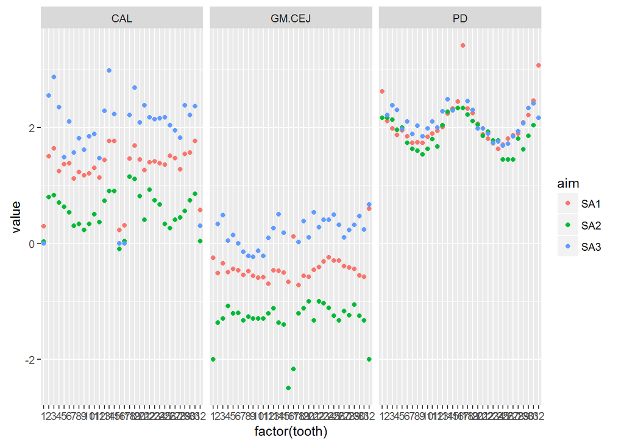

```r
library(ggplot2)
perio.nobop <- subset(perio, variable !="BOP")
ggplot(perio.nobop, aes(x=factor(tooth), y=value, color=aim)) + stat_summary(fun.y="mean", geom="point")  + facet_wrap(~variable)
```

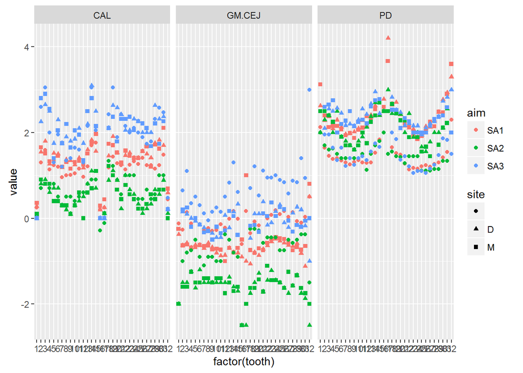

```r
#same plot, but with each variable for 'site' having a different shape

ggplot(perio.nobop, aes(x=factor(tooth), y=value, color=aim, shape = site)) + stat_summary(fun.y="mean", geom="point")  + facet_wrap(~variable)
```

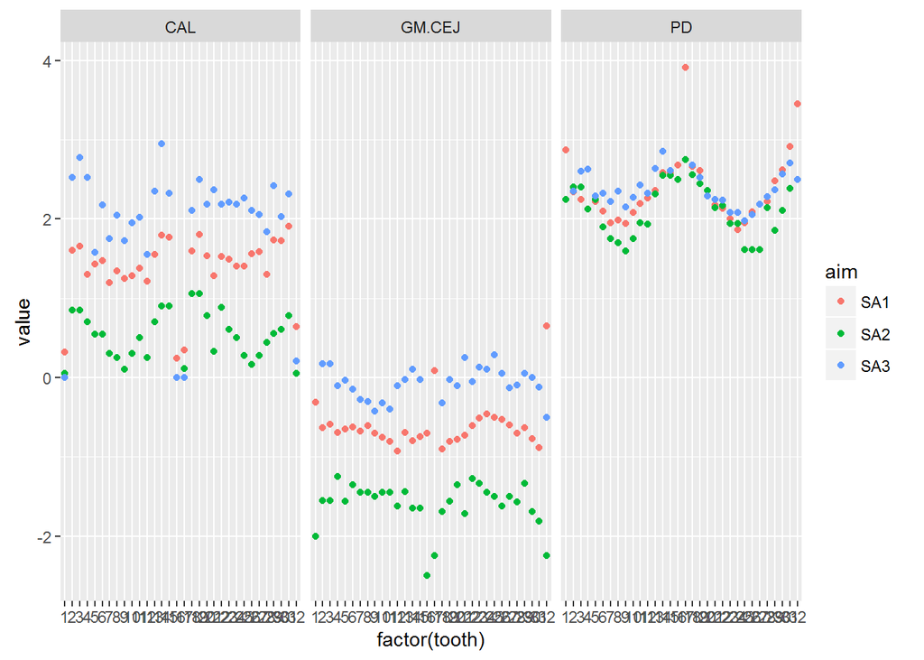

```r
#without mid measurements

perio.nobop.v2 <- subset(perio.no.front, variable !="BOP")
ggplot(perio.nobop.v2, aes(x=factor(tooth), y=value, color=aim)) + stat_summary(fun.y="mean", geom="point")  + facet_wrap(~variable)
```

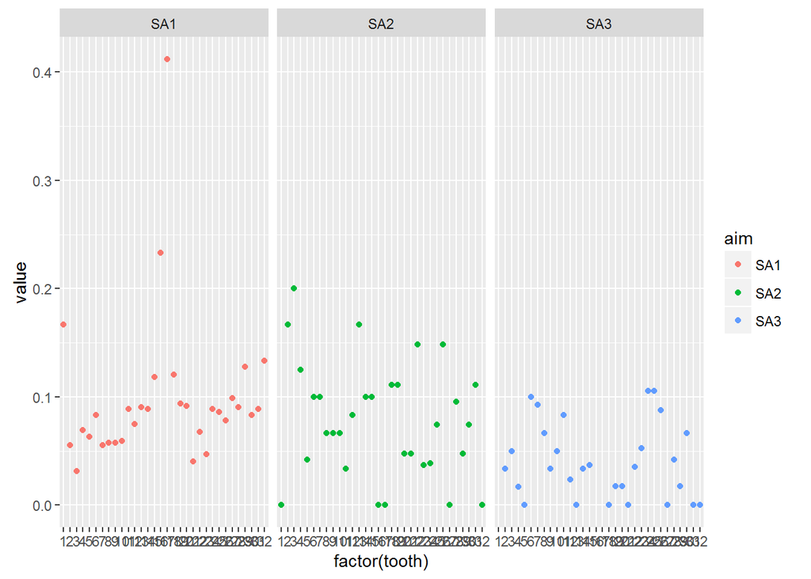

```r
#BOP
bop <- subset(perio, variable=="BOP")
ggplot(bop, aes(x=factor(tooth), y=value, color=aim)) + stat_summary(fun.y="mean", geom="point")  + facet_wrap(~aim)
```

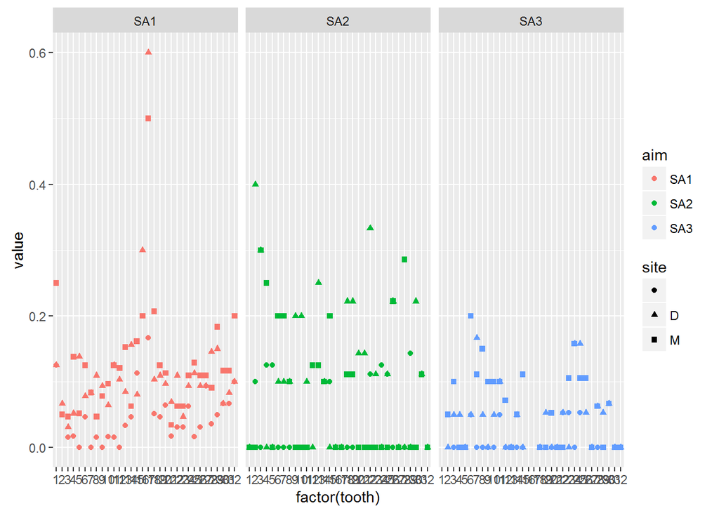

```r
#with site

ggplot(bop, aes(x=factor(tooth), y=value, color=aim, shape = site)) + stat_summary(fun.y="mean", geom="point")  + facet_wrap(~aim)
```

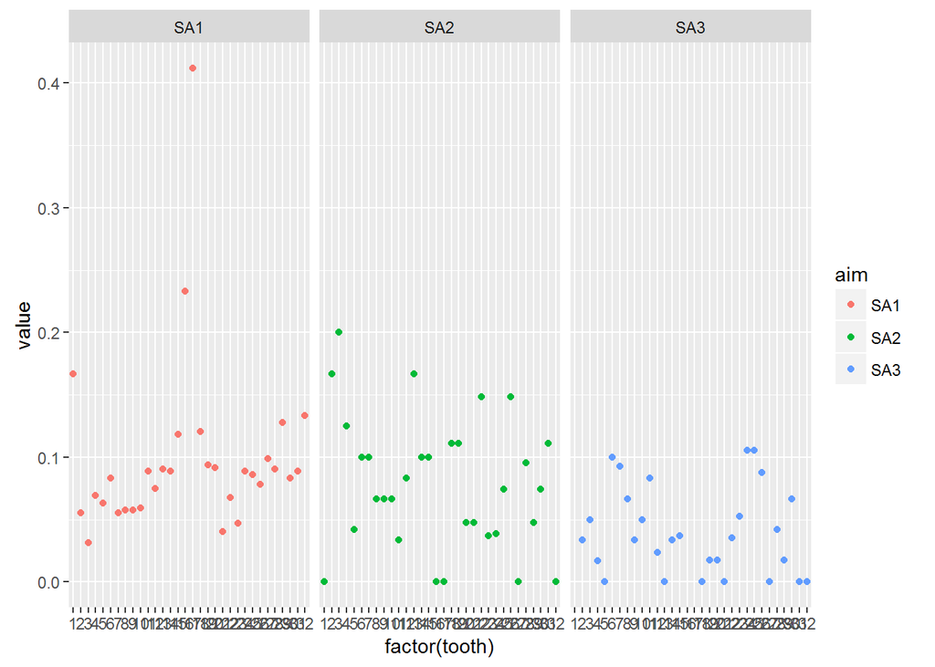

```r
#without mid measurements

bop.v2 <- subset(perio, variable=="BOP")
ggplot(bop, aes(x=factor(tooth), y=value, color=aim)) + stat_summary(fun.y="mean", geom="point")  + facet_wrap(~aim)
```

```r
#generate aim 1 counts
aim1 <- subset(bop, aim=="SA1")
a1_sum <- data.frame(table(aim1$value, aim1$tooth))
a1_sum$aim <- "SA1"
colnames(a1_sum) <- c("State", "Site", "Count", "Aim")
#generate aim 3 counts
aim3 <- subset(bop, aim=="SA3")
a3_sum <- data.frame(table(aim3$value, aim3$tooth))
a3_sum$aim <- "SA3"
colnames(a3_sum) <- c("State", "Site", "Count", "Aim")
bop_sum <- rbind(a1_sum, a3_sum)

##### WITHOUT MID MEASUREMENTS

#generate aim 1 counts
aim1.v2 <- subset(bop.v2, aim=="SA1")
a1_sum.v2 <- data.frame(table(aim1.v2$value, aim1.v2$tooth))
a1_sum.v2$aim <- "SA1"
colnames(a1_sum.v2) <- c("State", "Site", "Count", "Aim")
#generate aim 3 counts
aim3.v2 <- subset(bop.v2, aim=="SA3")
a3_sum.v2 <- data.frame(table(aim3.v2$value, aim3.v2$tooth))
a3_sum.v2$aim <- "SA3"
colnames(a3_sum.v2) <- c("State", "Site", "Count", "Aim")
bop_sum.v2 <- rbind(a1_sum.v2, a3_sum.v2)
```

## CAL

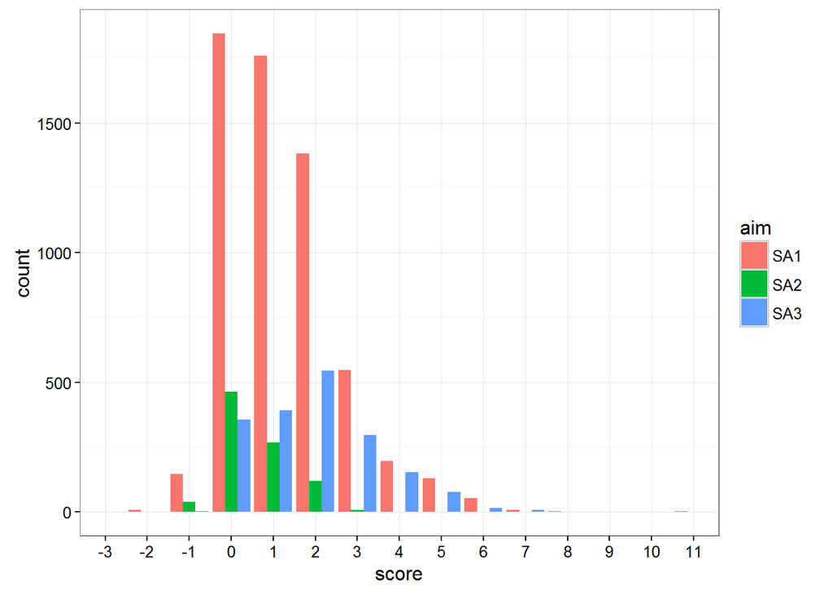

```r
cal <- subset(perio, variable=="CAL")
cal.tab <- data.frame(table(cal$value, cal$aim))
colnames(cal.tab) <- c("score", "aim", "count")
ggplot(cal.tab, aes(score, count, fill=aim)) + geom_bar(stat="identity", position="dodge") + theme_bw()
```

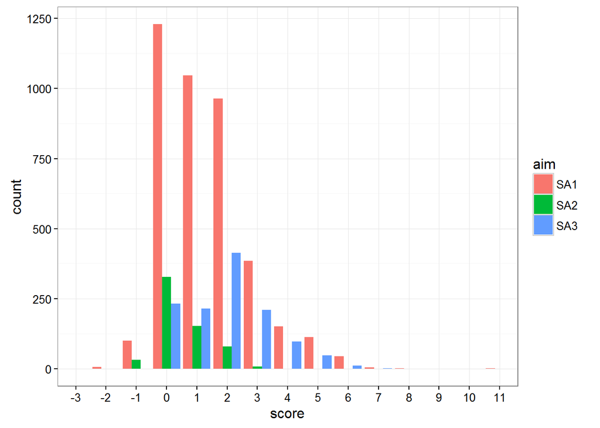

```r
#without mid measurements

cal.v2 <- subset(perio.no.front, variable=="CAL")
cal.tab.v2 <- data.frame(table(cal.v2$value, cal.v2$aim))
colnames(cal.tab.v2) <- c("score", "aim", "count")
ggplot(cal.tab.v2, aes(score, count, fill=aim)) + geom_bar(stat="identity", position="dodge") + theme_bw()
```

look at ANOVA, maybe ANCOVA, t-test, and chi-square, standard deviation, standard error and latin square